# Exploratory Data Analysis

### 7.3.4 Exercises

1. Explore the distribution of each of the `x`, `y`, and `z` variables in `diamonds`. What do you learn? Think about a diamond and how you might decide which dimension is the length, width, and depth.

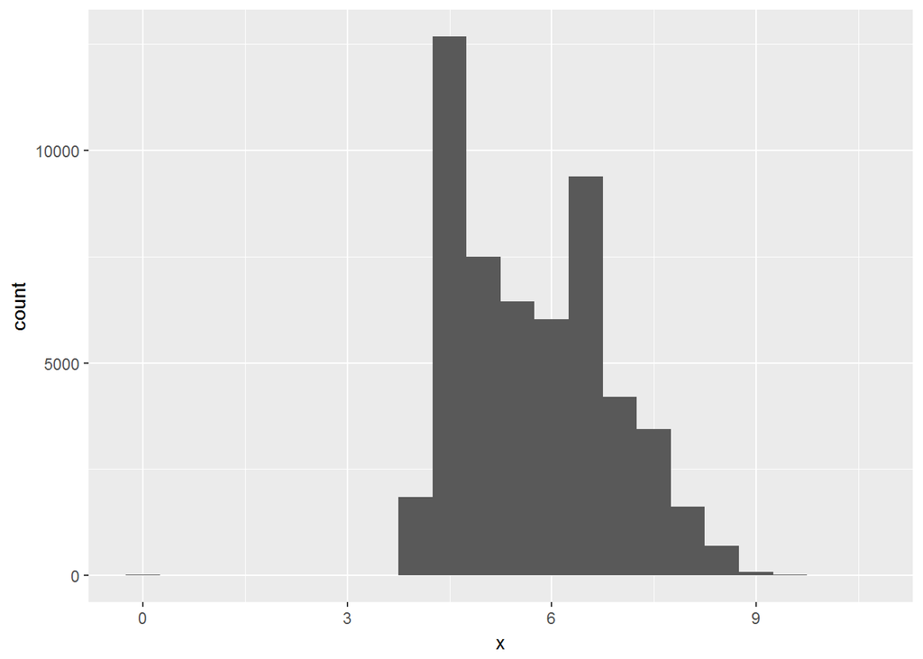

```r
ggplot(data = diamonds) +
  geom_histogram(mapping = aes(x = x), binwidth = 0.5)
```

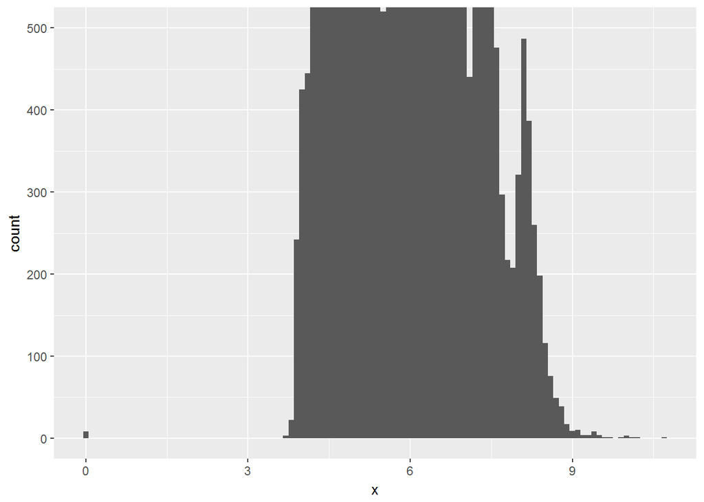

```r
ggplot(data = diamonds) +
  geom_histogram(mapping = aes(x = x), binwidth = 0.1) +
  coord_cartesian(ylim = c(0, 500))
```

```r
diamonds %>%
  count(cut_width(x, 0.5))
```

```
## # A tibble: 16 x 2
##    `cut_width(x, 0.5)`     n
##                 <fctr> <int>
##  1        [-0.25,0.25]     8
##  2         (3.25,3.75]     3
##  3         (3.75,4.25]  1834
##  4         (4.25,4.75] 12680
##  5         (4.75,5.25]  7502
##  6         (5.25,5.75]  6448
##  7         (5.75,6.25]  6031
##  8         (6.25,6.75]  9381
##  9         (6.75,7.25]  4193
## 10         (7.25,7.75]  3437
## 11         (7.75,8.25]  1620
## 12         (8.25,8.75]   699
## 13         (8.75,9.25]    79
## 14         (9.25,9.75]    18
## 15         (9.75,10.2]     6
## 16         (10.2,10.8]     1
```

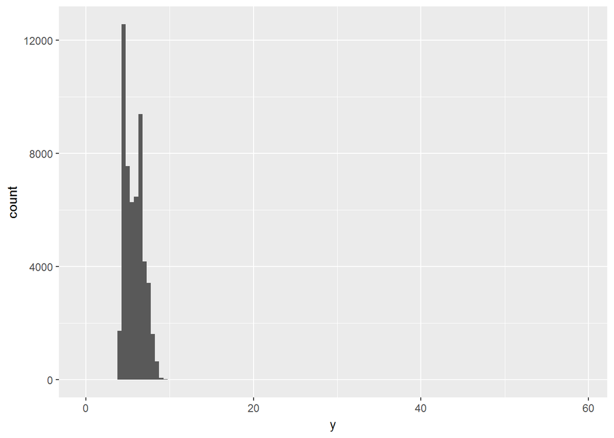

```r
ggplot(data = diamonds) +
  geom_histogram(mapping = aes(x = y), binwidth = 0.5)
```

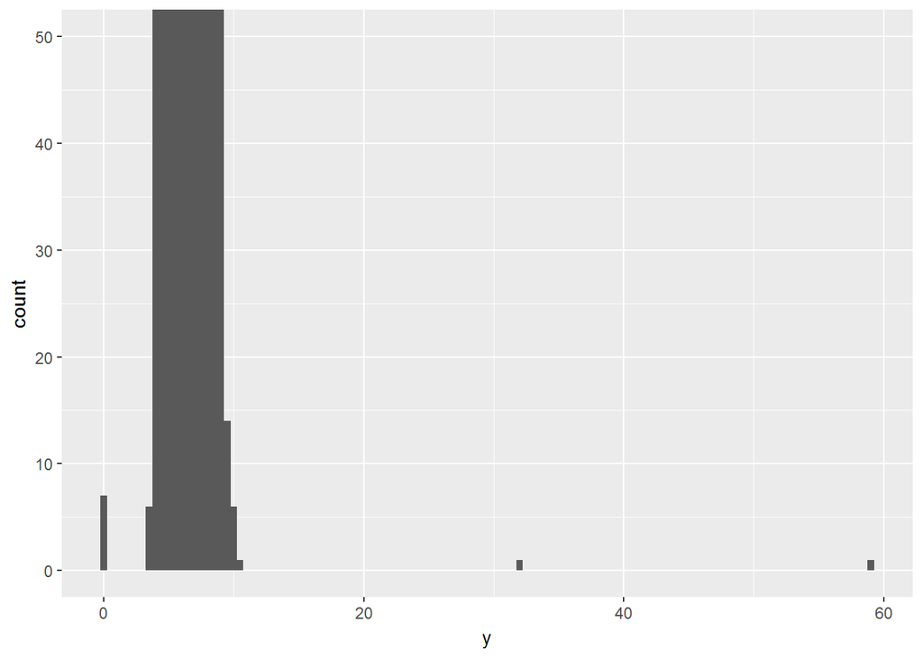

```r
ggplot(data = diamonds) +
  geom_histogram(mapping = aes(x = y), binwidth = 0.5) +
  coord_cartesian(ylim = c(0, 50))
```

```r
diamonds %>%
  count(cut_width(y, 0.5))
```

```
## # A tibble: 18 x 2
##    `cut_width(y, 0.5)`     n
##                 <fctr> <int>
##  1        [-0.25,0.25]     7
##  2         (3.25,3.75]     6
##  3         (3.75,4.25]  1730
##  4         (4.25,4.75] 12566
##  5         (4.75,5.25]  7556
##  6         (5.25,5.75]  6272
##  7         (5.75,6.25]  6464
##  8         (6.25,6.75]  9382
##  9         (6.75,7.25]  4176
## 10         (7.25,7.75]  3425
## 11         (7.75,8.25]  1612
## 12         (8.25,8.75]   654
## 13         (8.75,9.25]    67
## 14         (9.25,9.75]    14
## 15         (9.75,10.2]     6
## 16         (10.2,10.8]     1
## 17         (31.8,32.2]     1
## 18         (58.8,59.2]     1
```

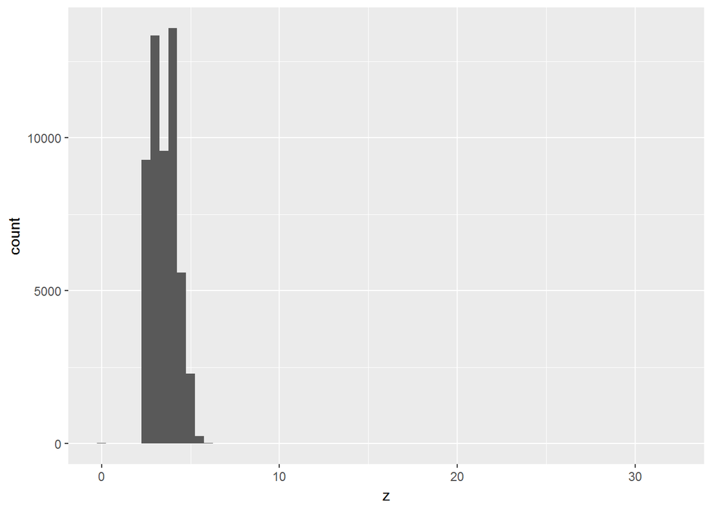

```r
ggplot(data = diamonds) +
  geom_histogram(mapping = aes(x = z), binwidth = 0.5)
```

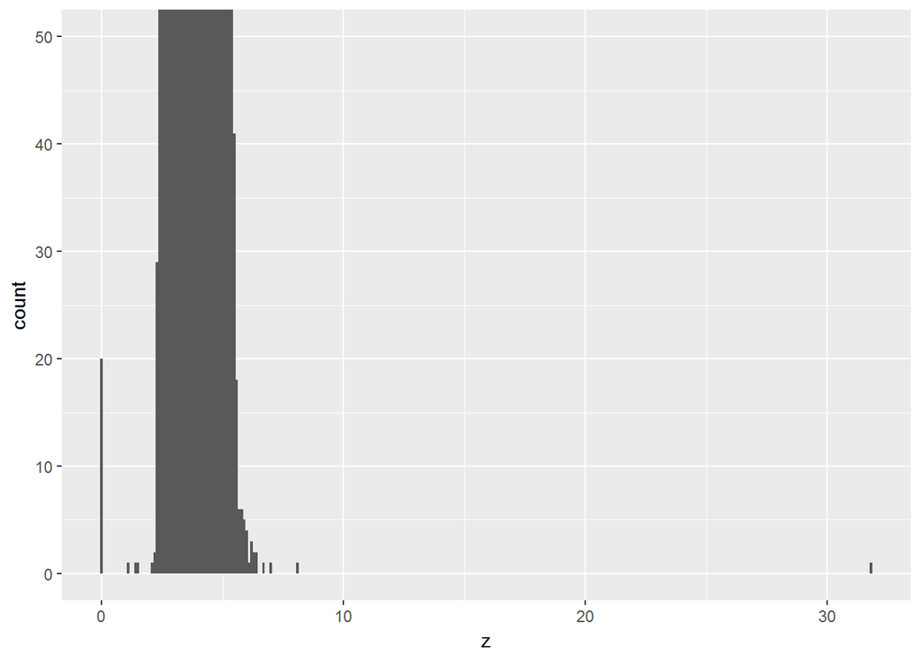

```r
ggplot(data = diamonds) +
  geom_histogram(mapping = aes(x = z), binwidth = 0.1) +
  coord_cartesian(ylim = c(0, 50))
```

```r
diamonds %>%
  count(cut_width(z, 0.5))
```

```
## # A tibble: 16 x 2
##    `cut_width(z, 0.5)`     n
##                 <fctr> <int>
##  1        [-0.25,0.25]    20
##  2         (0.75,1.25]     1
##  3         (1.25,1.75]     2
##  4         (1.75,2.25]     3
##  5         (2.25,2.75]  9276
##  6         (2.75,3.25] 13340
##  7         (3.25,3.75]  9572
##  8         (3.75,4.25] 13584
##  9         (4.25,4.75]  5589
## 10         (4.75,5.25]  2288
## 11         (5.25,5.75]   238
## 12         (5.75,6.25]    19
## 13         (6.25,6.75]     5
## 14         (6.75,7.25]     1
## 15         (7.75,8.25]     1
## 16         (31.8,32.2]     1
```

There are a number of outliers in each distribution that require further investigation.

As seen when you compute the bin widths and corresponding counts by hand, the most common value for `x` and `y` is between 4.25 and 4.75. For `z`, the most common value is between 3.75 and 4.25. The bin width from 2.75 to 3.25 is also very common. Based on these values, `x` and `y` appear to be the length and width of the diamond, while `z` is most likely the depth. This is confirmed in the documentation (`?diamonds`).

2. Explore the distribution of `price`. Do you discover anything unusual or surprising? (Hint: Carefully think about the `binwidth` and make sure you try a wide range of values.)

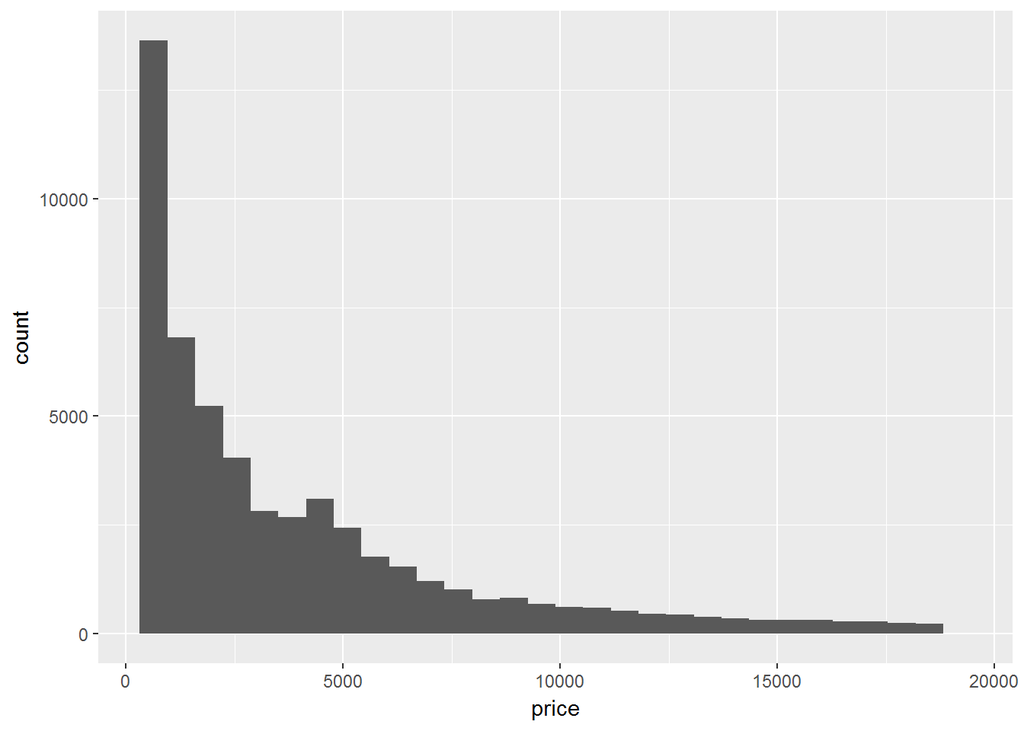

```r
ggplot(data = diamonds) +
  geom_histogram(mapping = aes(x = price))
```

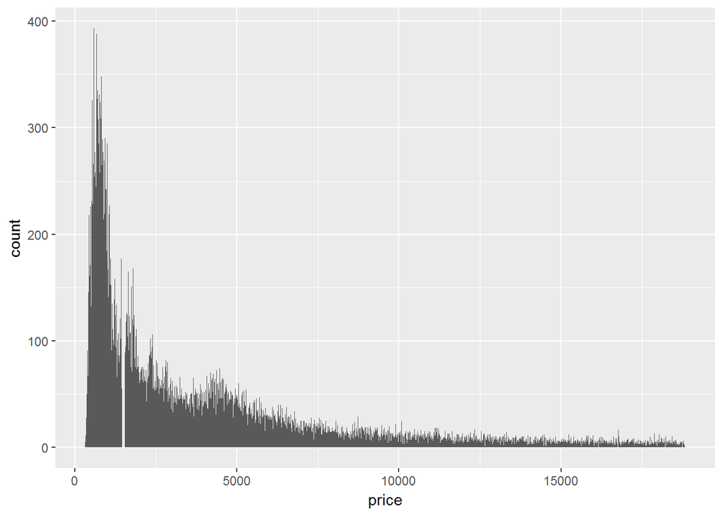

```r
ggplot(data = diamonds) +
  geom_histogram(mapping = aes(x = price), binwidth = 10)
```

3. How many diamonds are 0.99 carat? How many are 1 carat? What do you think is the cause of the difference?

```r
diamonds %>%
  count(carat) %>%
  filter(carat %in% c(0.99, 1))
```

```
## # A tibble: 2 x 2
##   carat     n
##   <dbl> <int>
## 1  0.99    23
## 2  1.00  1558
```

23 diamonds are 0.99 carat. In comparison, there are over 1,558 diamonds that are 1 carat.

Maybe 0.99 carat diamonds are more likely to be rounded up.

```r
diamonds %>%
  filter(carat == 0.99) %>%
  select(carat, cut, price, x, y, z)
```

```
## # A tibble: 23 x 6
##    carat       cut price     x     y     z
##    <dbl>     <ord> <int> <dbl> <dbl> <dbl>
##  1  0.99      Fair  2811  6.21  6.06  4.18
##  2  0.99      Fair  2812  6.72  6.67  3.68
##  3  0.99      Fair  2949  6.57  6.50  3.79
##  4  0.99      Fair  3337  6.42  6.34  3.87
##  5  0.99      Fair  3593  5.94  5.80  4.20
##  6  0.99 Very Good  4002  6.44  6.49  3.90
##  7  0.99      Good  4052  6.36  6.43  4.05
##  8  0.99   Premium  4075  6.45  6.38  3.89
##  9  0.99     Ideal  4763  6.40  6.42  3.96
## 10  0.99 Very Good  4780  6.30  6.33  3.90
## # ... with 13 more rows
```

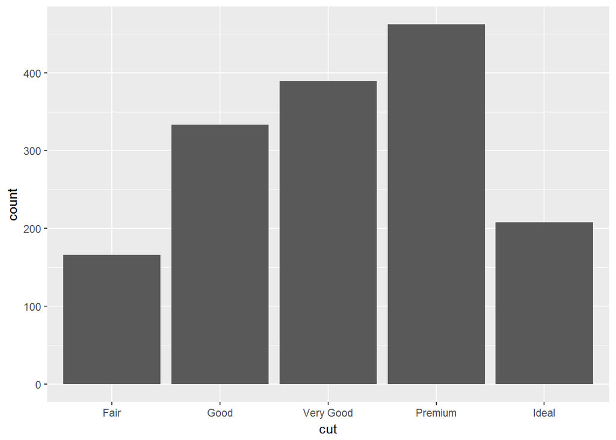

```r
diamonds %>%
  filter(carat == 1) %>%
  select(carat, cut, price, x, y, z) %>%
  ggplot(mapping = aes(x = cut)) +
  geom_bar()
```

```r
diamonds %>%
  filter(carat == 1) %>%
  select(price) %>%
  summary(price)
```

```
##      price
##  Min.   : 1681
##  1st Qu.: 4155
##  Median : 4864
##  Mean   : 5242
##  3rd Qu.: 6073
##  Max.   :16469
```

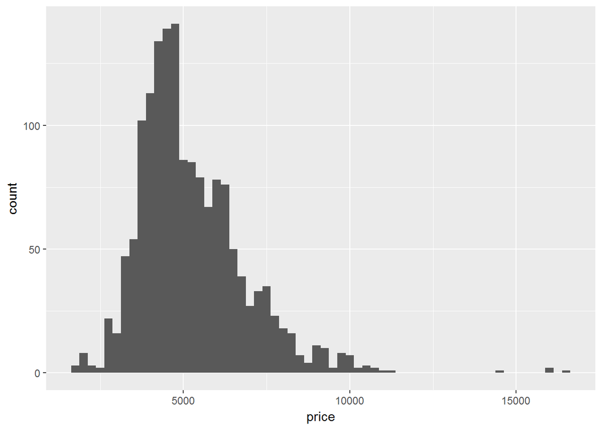

```r
diamonds %>%
  filter(carat == 1) %>%
  select(carat, cut, price, x, y, z) %>%
  ggplot(mapping = aes(x = price)) +
  geom_histogram(binwidth = 250)
```

4. Compare and contrast `coord_cartesian()` vs `xlim()` or `ylim()` when zooming in on a histogram. What happens if you leave `binwidth` unset? What happens if you try and zoom so only half a bar shows?

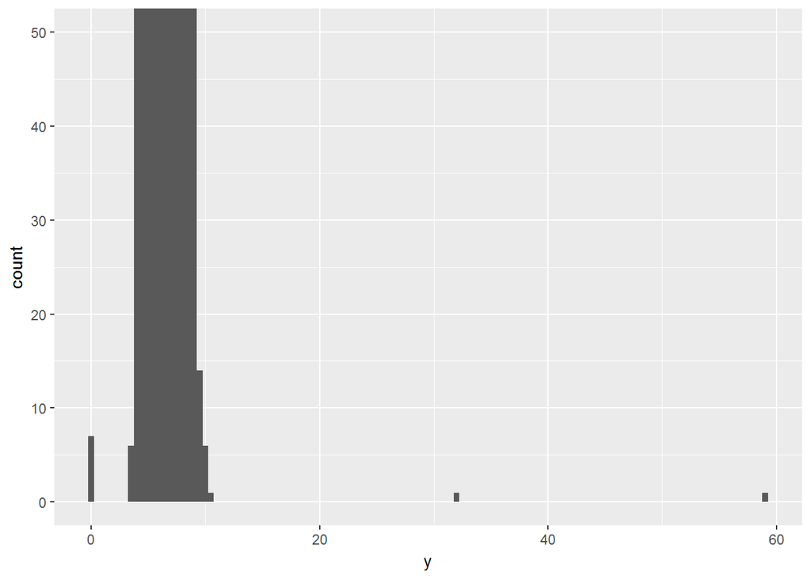

```r
ggplot(diamonds) +
  geom_histogram(mapping = aes(x = y), binwidth = 0.5) +
  coord_cartesian(ylim = c(0, 50))
```

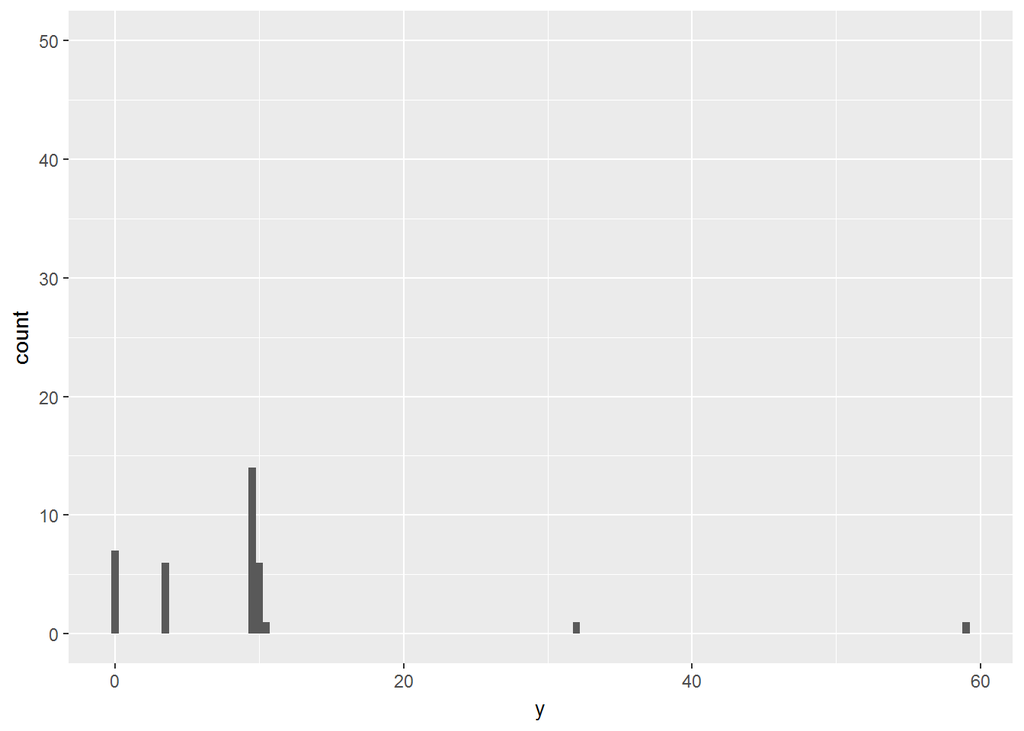

```r
ggplot(diamonds) +
  geom_histogram(mapping = aes(x = y), binwidth = 0.5) +
  ylim(0, 50)
```

`xlim()` and `ylim()` throw away data outside the limits.

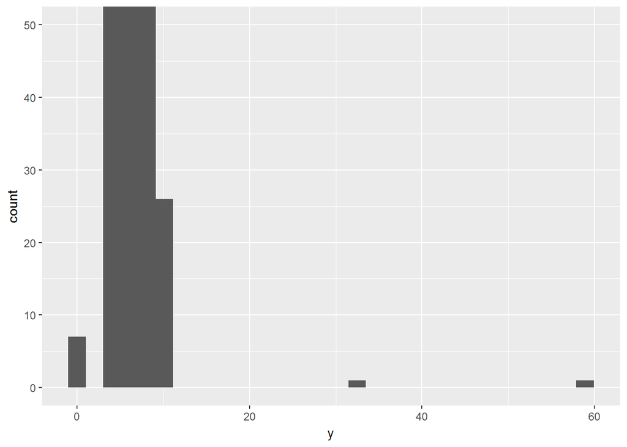

```r
ggplot(diamonds) +
  geom_histogram(mapping = aes(x = y)) +
  coord_cartesian(ylim = c(0, 50))
```

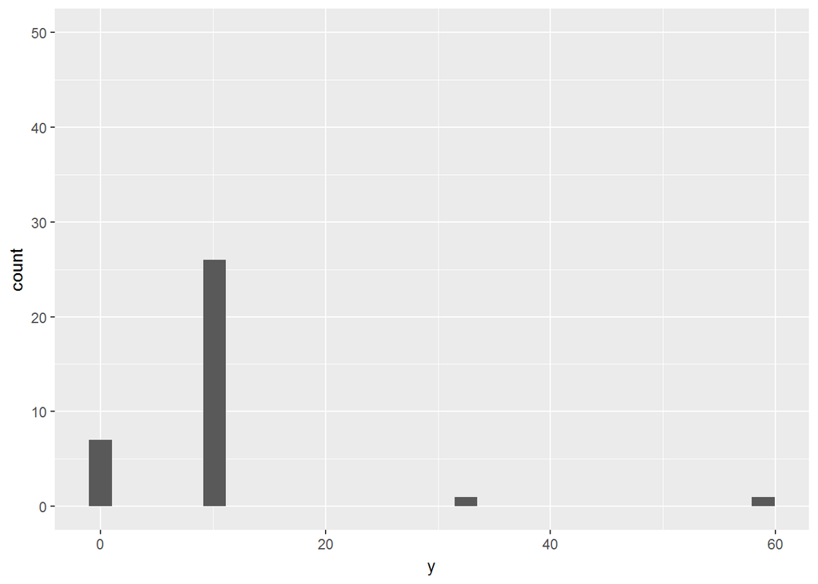

```r
ggplot(diamonds) +
  geom_histogram(mapping = aes(x = y)) +
  ylim(0, 50)
```

If `binwidth` is unset, it is easier to discern the bars when zooming in on a plot.

If you try to zoom with `xlim()` or `ylim()` so only half a bar shows, the data in that binwidth will be thrown away. So, the bar will disappear from the plot.

### 7.4.1 Exercises

1. What happens to missing values in a histogram? What happens to missing values in a bar chart? Why is there a difference?

In a histogram and bar chart, by default, missing values are removed with a warning. So, there is no actual difference as the question indicates.

2. What does `na.rm = TRUE` do in `mean()` and `sum()`?

It removes missing values before the computation proceeds.

### 7.5.1.1 Exercises

1. Use what you’ve learned to improve the visualisation of the departure times of cancelled vs. non-cancelled flights.

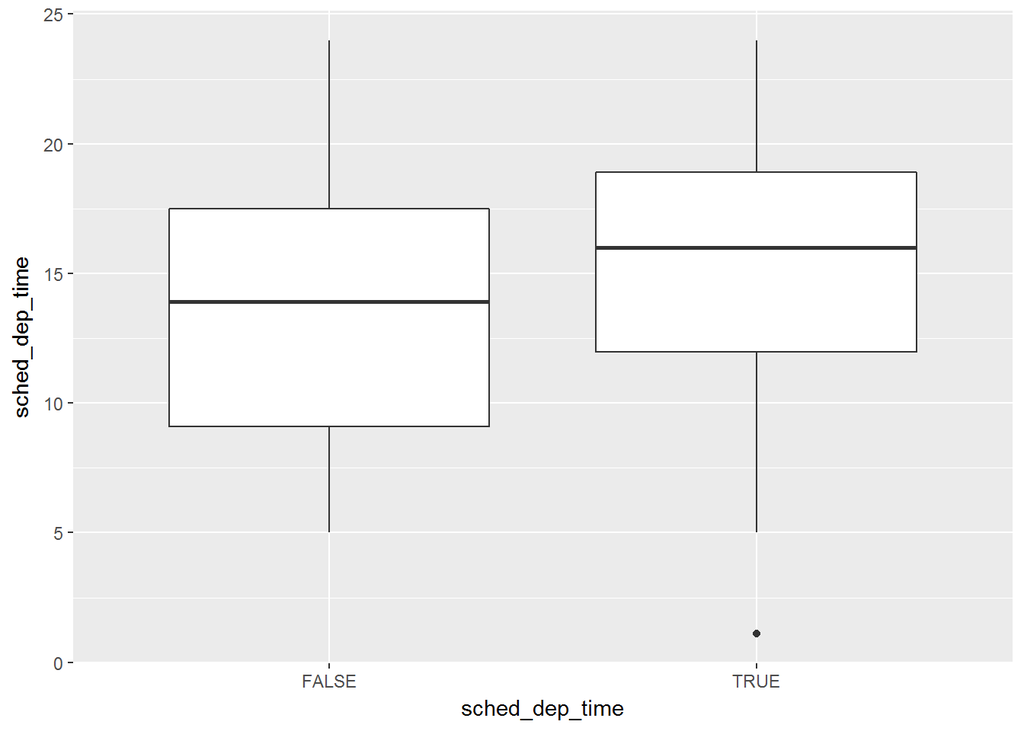

```r
flights %>%
  mutate(
    cancelled = is.na(dep_time),
    sched_hour = sched_dep_time %/% 100,
    sched_min = sched_dep_time %% 100,
    sched_dep_time = sched_hour + sched_min / 60
  ) %>%
  ggplot(mapping = aes(sched_dep_time)) +
    geom_boxplot(mapping = aes(x = cancelled, y = sched_dep_time))
```

2. What variable in the diamonds dataset is most important for predicting the price of a diamond? How is that variable correlated with cut? Why does the combination of those two relationships lead to lower quality diamonds being more expensive?

Return to this question after completing the section on modelling. If I had to guess, I think `carat` might be the most important for predicting the price of a diamond. There is an exponential relationship between `carat` and `price`:

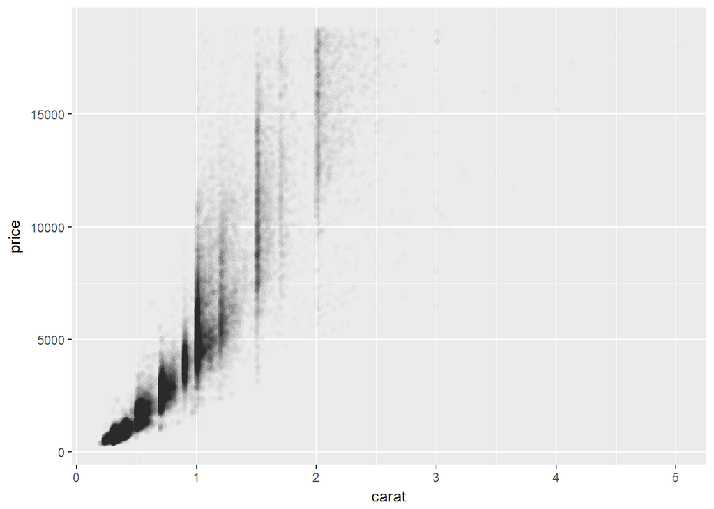

```r
ggplot(diamonds, mapping = aes(x = carat, y = price)) +
  geom_point(alpha = 1/100)
```

3. Install the ggstance package, and create a horizontal boxplot. How does this compare to using `coord_flip()`?

`ggstance` provides flipped versions of geoms, stats, and positions. This means you can provide aesthetics in their natural order, making the code more readable:

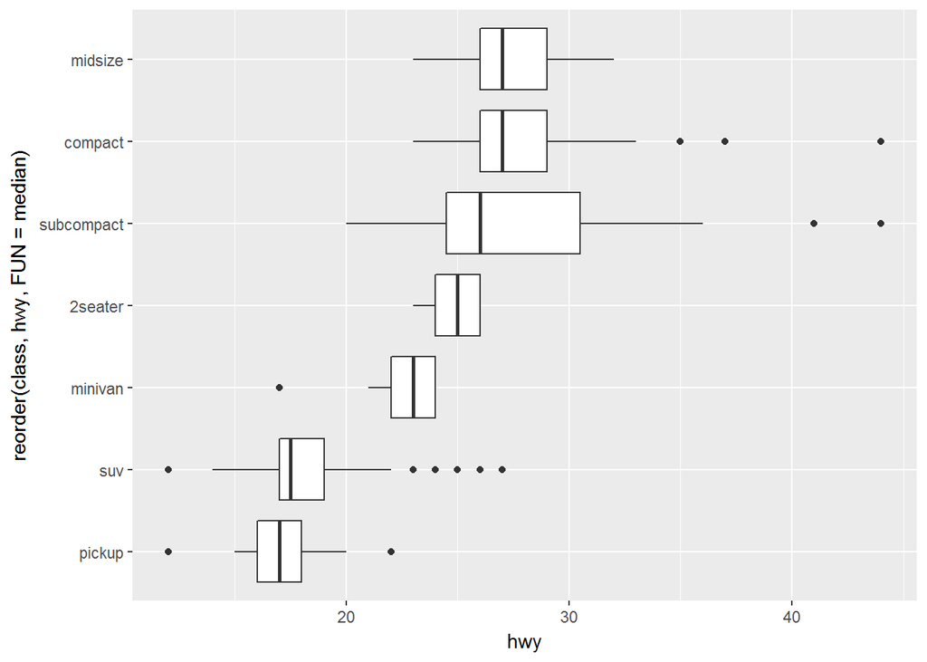

```r
ggplot(data = mpg) +
  geom_boxploth(mapping = aes(x = hwy, y = reorder(class, hwy, FUN = median)))
```

In comparsion, `coord_flip()` can only flip the plot as a whole.

4. One problem with boxplots is that they were developed in an era of much smaller datasets and tend to display a prohibitively large number of “outlying values”. One approach to remedy this problem is the letter value plot. Install the lvplot package, and try using `geom_lv()` to display the distribution of price vs cut. What do you learn? How do you interpret the plots?

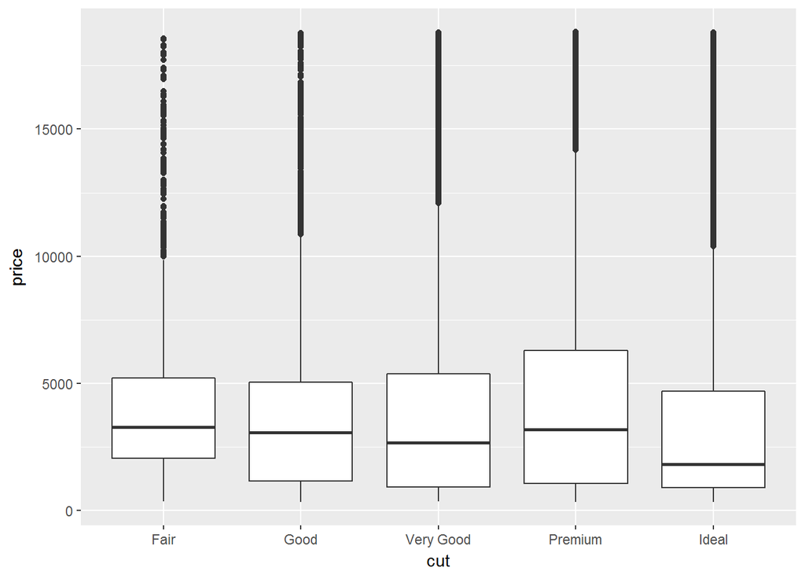

```r
ggplot(diamonds) +
  geom_boxplot(mapping = aes(x = cut, y = price))
```

The boxplots show many outliers, which is typical for large sample sizes (*n > 1000*).

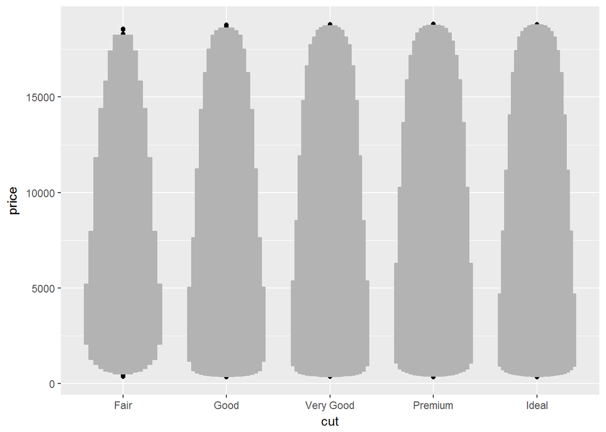

```r
ggplot(data = diamonds) +
  geom_lv(mapping = aes(x = cut, y = price))
```

Using the more precise (for *n > 1000*) letter-value box plots, there are less outliers. With letter-value box plots, the fattest box indicates the IQR.

5. Compare and contrast `geom_violin()` with a facetted `geom_histogram()`, or a coloured `geom_freqpoly()`. What are the pros and cons of each method?

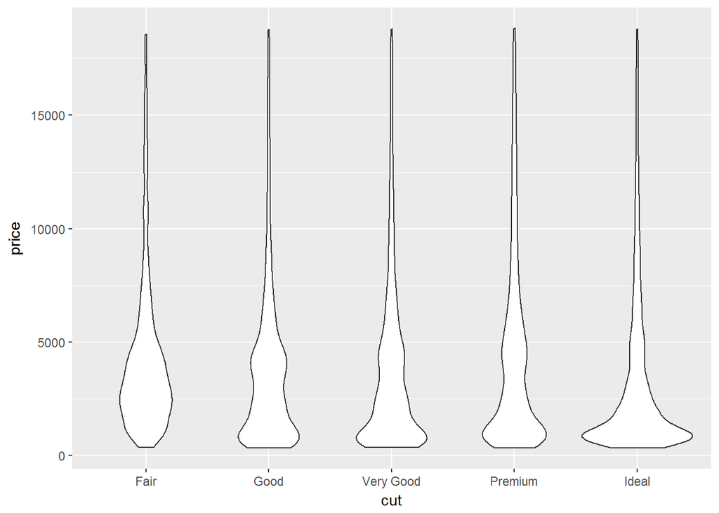

```r
ggplot(diamonds) +
  geom_violin(mapping = aes(x = cut, y = price))
```

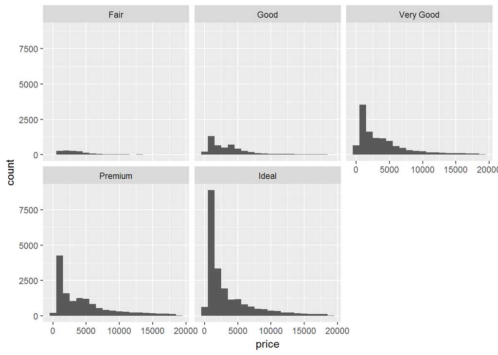

```r
ggplot(diamonds) +
  geom_histogram(mapping = aes(x = price), binwidth = 1000) +
  facet_wrap(~ cut)
```

`geom_violin()` displays everything in one plot. However, it only shows the variability within the `cut` variable. In comparison, the facetted `geom_histogram()` shows the overall count for each binwidth. So, from the facetted histogram, it can be seen that not many diamonds have `cut == Fair` compared to, say, `cut == Ideal`.

6. If you have a small dataset, it’s sometimes useful to use `geom_jitter()` to see the relationship between a continuous and categorical variable. The ggbeeswarm package provides a number of methods similar to `geom_jitter()`. List them and briefly describe what each one does.

ggbeeswarm provides two methods to reduce overplotting: `geom_quasirandom` and `geom_beeswarm`. Both methods show the density of the data at each point, while still showing each individual point.

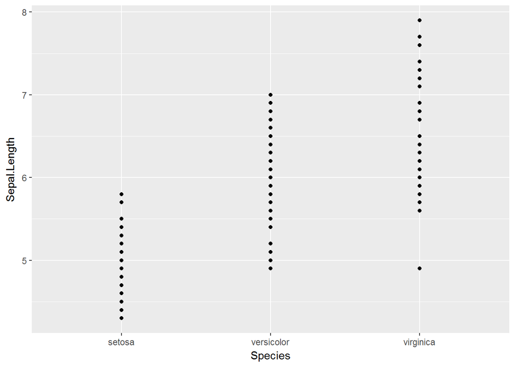

```r
ggplot(iris,aes(Species, Sepal.Length)) +
  geom_point()
```

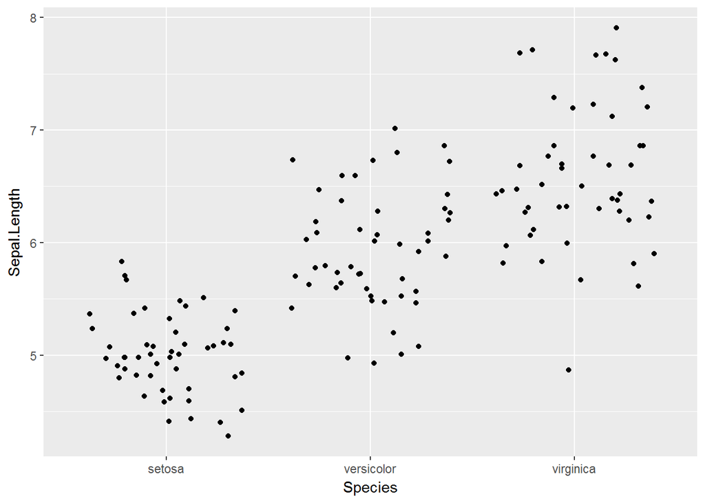

```r
ggplot(iris,aes(Species, Sepal.Length)) +
  geom_jitter()
```

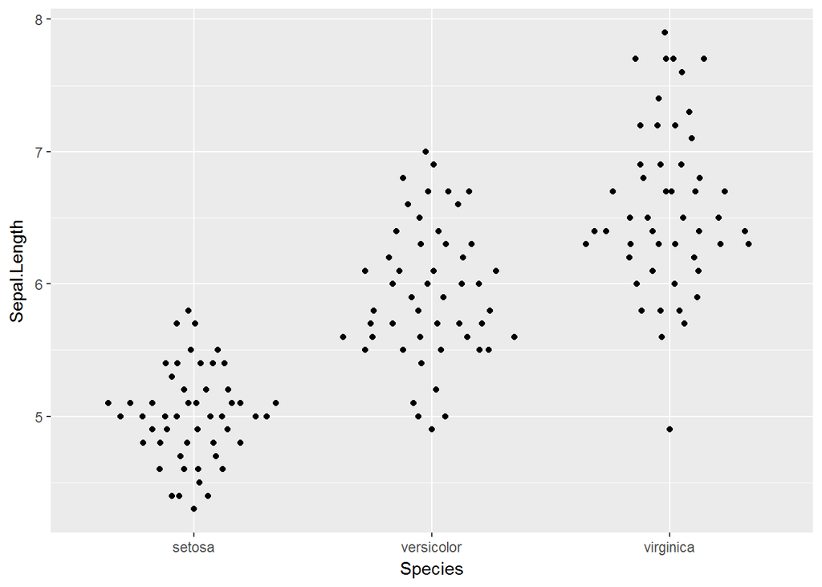

```r
ggplot(iris, mapping = aes(Species, Sepal.Length)) +
  geom_quasirandom()
```

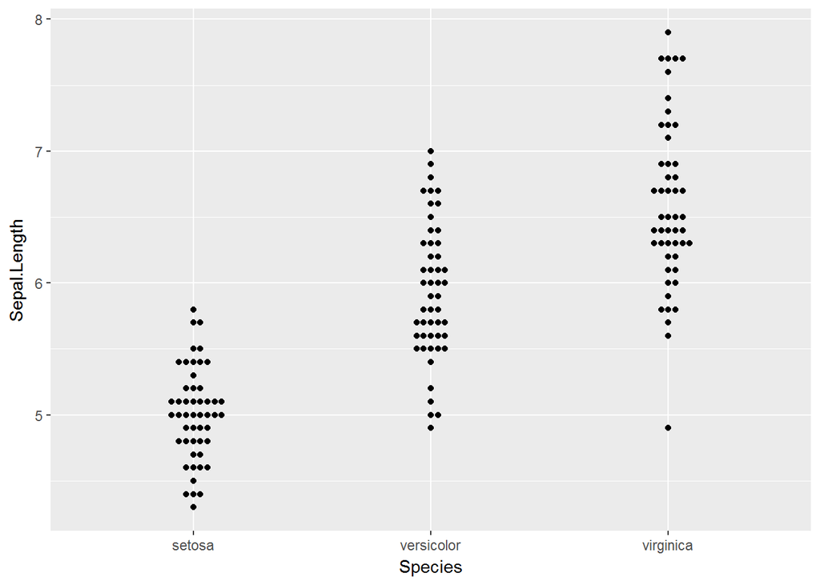

```r
ggplot(iris, mapping = aes(Species, Sepal.Length)) +
  geom_beeswarm()
```

`geom_quasirandom` spaces dots using a [van der Corput sequence](https://en.wikipedia.org/wiki/Van_der_Corput_sequence) or Tukey texturing. In comparison, `geom_beeswarm` uses the beeswarm library.

### 7.5.2.1 Exercises

1. How could you rescale the count dataset above to more clearly show the distribution of cut within colour, or colour within cut?

```r
diamonds %>%
  count(cut, color)
```

```
## # A tibble: 35 x 3
##      cut color     n
##    <ord> <ord> <int>
##  1  Fair     D   163
##  2  Fair     E   224
##  3  Fair     F   312
##  4  Fair     G   314
##  5  Fair     H   303
##  6  Fair     I   175
##  7  Fair     J   119
##  8  Good     D   662
##  9  Good     E   933
## 10  Good     F   909
## # ... with 25 more rows
```

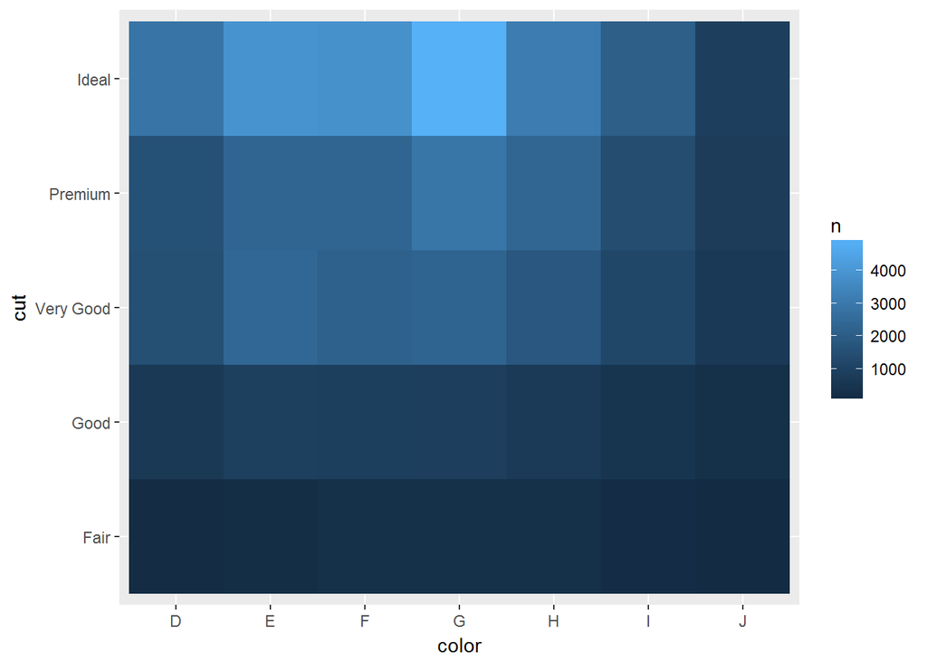

```r
diamonds %>%
  count(color, cut) %>%
  ggplot(mapping = aes(x = color, y = cut)) +
    geom_tile(mapping = aes(fill = n))
```

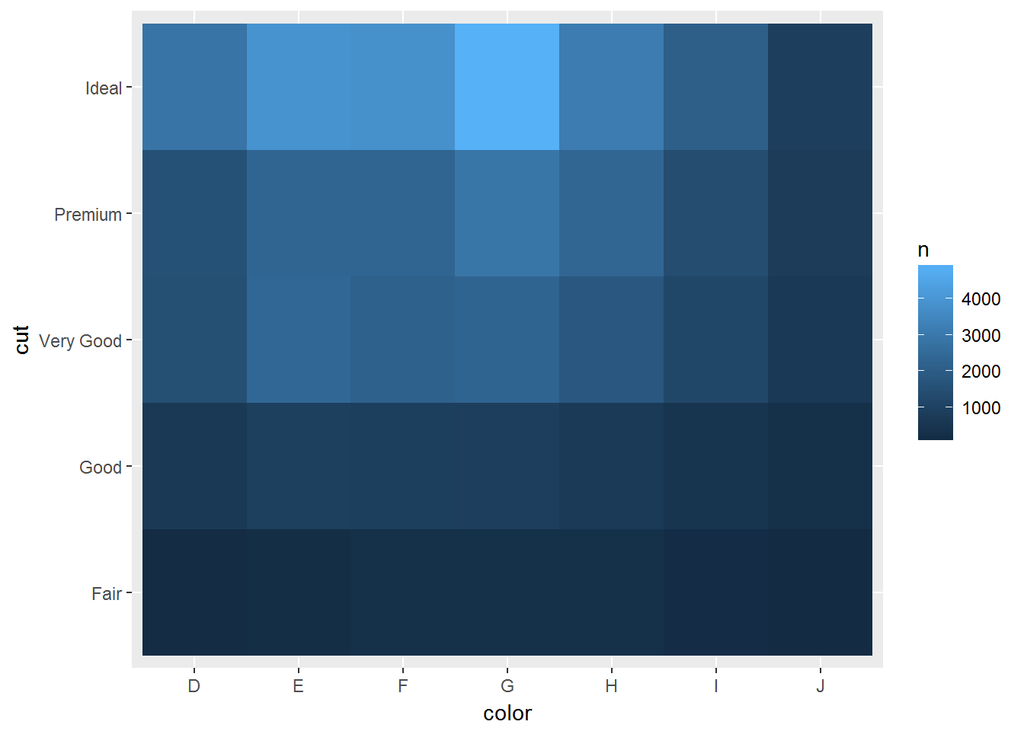

```r
diamonds %>%
  count(cut, color) %>%
  ggplot(mapping = aes(x = color, y = cut)) +
    geom_tile(mapping = aes(fill = n))
```

2. Use `geom_tile()` together with dplyr to explore how average flight delays vary by destination and month of year. What makes the plot difficult to read? How could you improve it?

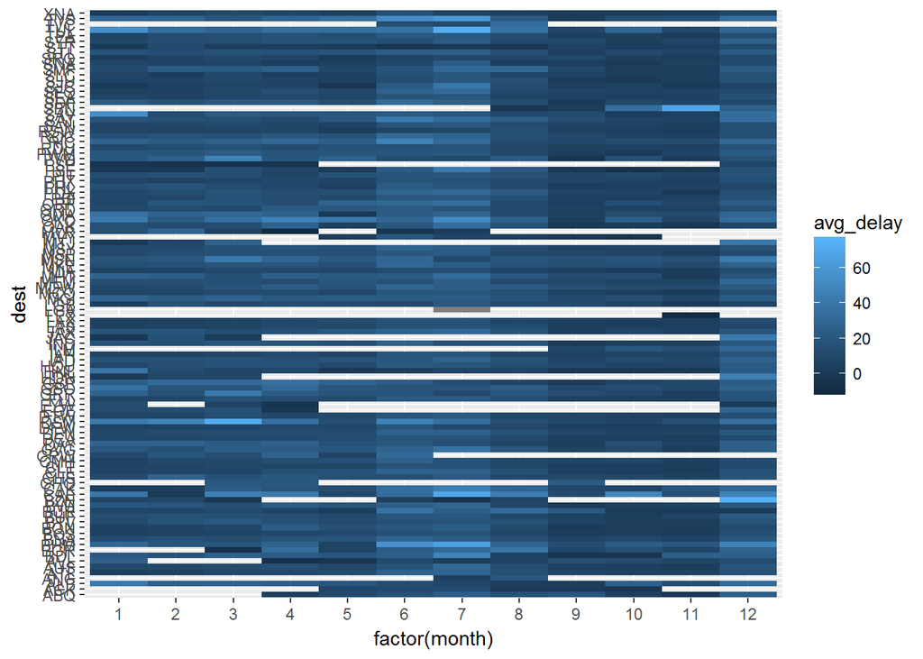

```r
flights %>%
  group_by(month, dest) %>%
  summarise(avg_delay = mean(dep_delay, na.rm = TRUE)) %>%
  ggplot(mapping = aes(x = factor(month), y = dest)) +
    geom_tile(mapping = aes(fill = avg_delay))
```

The plot is difficult to read because there are many destinations on the y-axis. There are also missing values that could be removed to improve readability.

3. Why is it slightly better to use `aes(x = color, y = cut)` rather than `aes(x = cut, y = color)` in the example above?

### 7.5.3.1 Exercises

1. Instead of summarising the conditional distribution with a boxplot, you could use a frequency polygon. What do you need to consider when using `cut_width()` vs `cut_number()`? How does that impact a visualisation of the 2d distribution of `carat` and `price`?